# Week4Assignment

Ken Gu

2017年3月4日

Executive Summary: Background: A magazine (Motor Trend) about the automobile industry. Looking at a data set of a collection of cars, they are interested in exploring the relationship between a set of variables and miles per gallon (MPG) (outcome). They are particularly interested in the following two questions:

“Is an automatic or manual transmission better for MPG” “Quantify the MPG difference between automatic and manual transmissions”

Multivariable model selection strategy: We use nested likelikhood ratio tests for model selection. In detail: Given a coefficient that I’m interested in, I like to use covariate adjustment and multiple models to probe that effect to evaluate it for robustness and to see what other covariates knock it out or amplify it. In other words, if I have an effect, or absence of an effect, that I’d like to report, I try to first come up with criticisms of that effect and then use models to try to answer those criticisms.

Step 1: load library and data

```r
library(ggplot2)
library(dplyr)
library(car)
data(mtcars)
datamtcars <- mutate(mtcars, amvar=as.factor(am))
```

Step 2: Data Cleaning

```r
# clean the data - add new variable - amvar - as factor
dataautocars <- filter(datamtcars, amvar==0)
datamanucars <- filter(datamtcars, amvar==1)
dataautocars$amvar = "auto"
datamanucars$amvar = "manual"
datamtcars <- data.frame()
datamtcars <- rbind(dataautocars, datamanucars)
datamtcars <- select(datamtcars, -am)
```

Step 3: Use explortory analysis to compare the automatic/manual vs mpg

```r
grp1 <- group_by(datamtcars, amvar)
datamean <- summarise (grp1, mean(mpg))
datamean
```

```
## # A tibble: 2 × 2
##    amvar `mean(mpg)`
##    <chr>       <dbl>
## 1   auto    17.14737
## 2 manual    24.39231
```

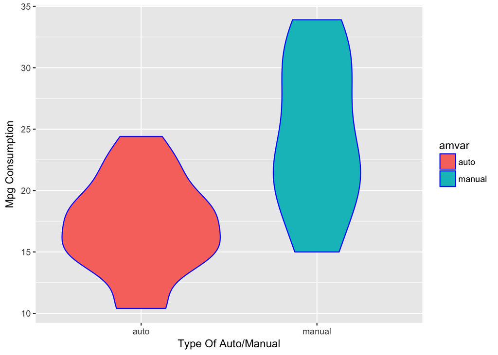

```r
g1 <- ggplot(data=datamtcars, aes(y=mpg, x=amvar, fill=amvar)) + geom_violin(colour="blue") + xlab("Type Of Auto/Manual") + ylab("Mpg Consumption")
g1
```

From the above plot, its clearly stated that the auto(red color) transmission has less MPG consumption Step 4: quantify the difference between automatic cars vs. manual cars for the mpg usage

```r
quantifyDiff <- datamean[1,2] - datamean[2,2]
quantifyDiff
```

```
##   mean(mpg)
## 1 -7.244939
```

The quantifiy difference between auto vs manual is 7.24 MPG

```r
fit2 <- lm(mpg~amvar, data=datamtcars)
rSingle <- summary(fit2)

resi <- resid(fit2)
testResult <- t.test(dataautocars$mpg, datamanucars$mpg)
```

Step 5: Evaluation On MultiVariables and finalize the selection

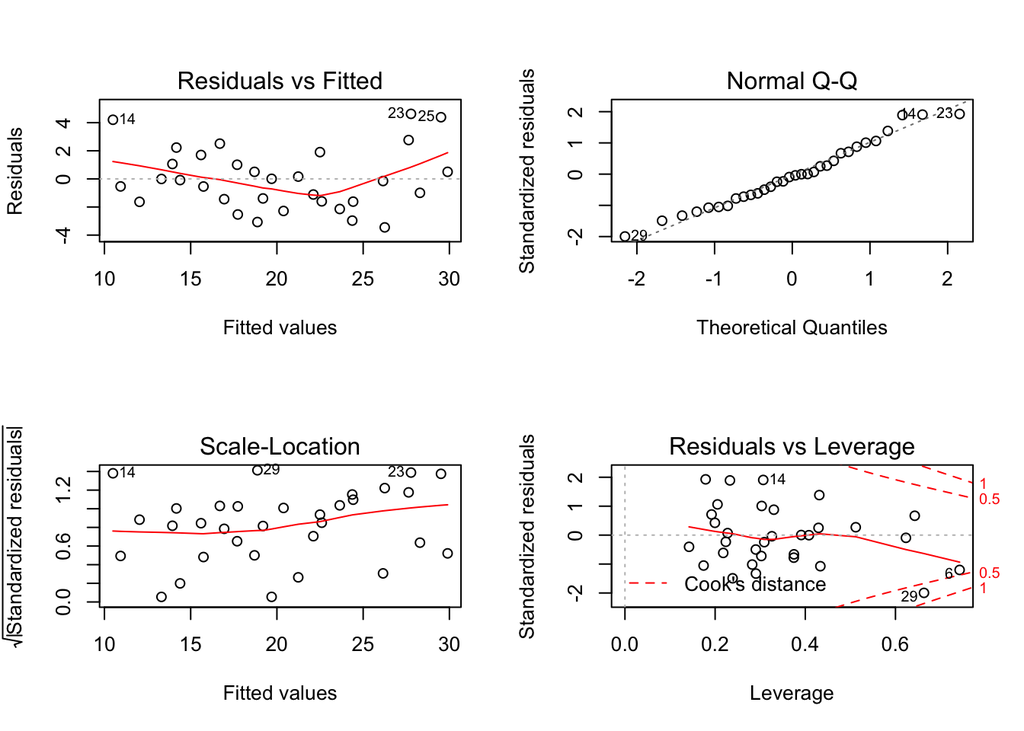

```r
fitall <- lm(mpg ~ ., datamtcars)
vifResult <- vif(fitall)
par(mfrow=c(2,2))
plot(fitall)
```

```r
# from the vif result, we pick up the most 4 observations - disp, cyl, wt, hp in addition to the amvar
fit3 <- update(fit2, mpg ~ amvar + disp)
fit4 <- update(fit2, mpg ~ amvar + disp + cyl)
fit5 <- update(fit2, mpg ~ amvar + disp + cyl + wt)
fit6 <- update(fit2, mpg ~ amvar + disp + cyl + wt + hp)

anovavalue <- anova(fit2, fit3, fit4, fit5, fit6)
anovavalue
```

[output not shown]

```
## Analysis of Variance Table
##
## Model 1: mpg ~ amvar
## Model 2: mpg ~ amvar + disp
## Model 3: mpg ~ amvar + disp + cyl
## Model 4: mpg ~ amvar + disp + cyl + wt
## Model 5: mpg ~ amvar + disp + cyl + wt + hp
##   Res.Df    RSS Df Sum of Sq       F    Pr(>F)
## 1     30 720.90
## 2     29 300.28  1    420.62 67.0427 1.141e-08 ***
## 3     28 252.08  1     48.20  7.6827  0.010165 *
## 4     27 188.43  1     63.66 10.1461  0.003736 **
## 5     26 163.12  1     25.31  4.0336  0.055097 .
## ---
## Signif. codes:  0 '***' 0.001 '**' 0.01 '*' 0.05 '.' 0.1 ' ' 1
```

```r
newMutliModel <- lm(mpg~amvar + disp + cyl + wt, datamtcars)
summaryMulti <- summary(newMutliModel)
summaryMulti
```

```
##
## Call:
## lm(formula = mpg ~ amvar + disp + cyl + wt, data = datamtcars)
##
## Residuals:
##    Min     1Q Median     3Q    Max
## -4.318 -1.362 -0.479  1.354  6.059
##
## Coefficients:
##              Estimate Std. Error t value Pr(>|t|)
## (Intercept) 40.898313   3.601540  11.356 8.68e-12 ***
## amvarmanual  0.129066   1.321512   0.098  0.92292
## disp         0.007404   0.012081   0.613  0.54509
## cyl         -1.784173   0.618192  -2.886  0.00758 **
## wt          -3.583425   1.186504  -3.020  0.00547 **
## ---
## Signif. codes:  0 '***' 0.001 '**' 0.01 '*' 0.05 '.' 0.1 ' ' 1
##
## Residual standard error: 2.642 on 27 degrees of freedom
## Multiple R-squared:  0.8327, Adjusted R-squared:  0.8079
## F-statistic: 33.59 on 4 and 27 DF,  p-value: 4.038e-10
```

Step 6: Calculate the residuals using plot

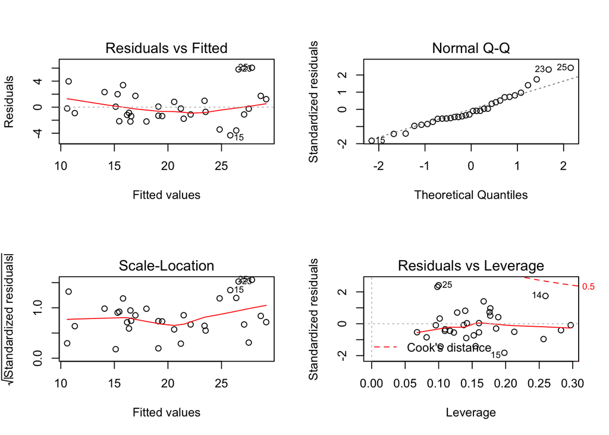

```r
par(mfrow=c(2,2))
plot(newMutliModel)
```

- From the new model, we see 81% of the variance. The multi variables shows that the question of auto car and manual car is not fully anwsered and the context of displacement, number of cylinders, weight should be taken into total consideration.